# RStudio server

2023-09-22

## What is RStudio server?

“RStudio Server enables you to run the RStudio IDE you know and love on a Linux server, accessed from your web browser, bringing the power and productivity of the RStudio IDE to a centralized server-based environment.”

## RStudio on DASH

The RStudio deployment on DASH is attached to Databricks clusters and storage.

## Accessing RStudio server

Access to RStudio server is through Databricks.  
Use the URL you have been given and login with your credentials.

On the left hand menu select “Compute”

[figure not shown]

Select a cluster from the list by clicking on it’s name.  
Make sure the cluster has a green tick in the “State” column to the left of the name. This indicates it is running, or “spun up”.

[figure not shown]

Select the app “Apps” at the top of the page.

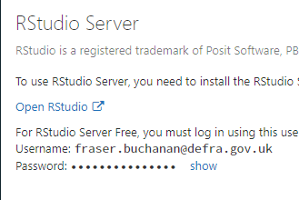

Click the “Show password” text.  
Double click the password to highlight it then copy it.  
(Right click and slect copy from menu or ctl-c)

[figure not shown]

Click the “open RStuido” text.  
Log in with your DASH username and the copied password.